NO SCRIPTS · NO PYTHON

# Static investigation worksheet

First visit? Read the introduction and normal waveform. Keep FEEDBACK_FORM.txt beside you, or use paper. Work through the four tasks in order.

Use paper or a text document to record predictions. Native disclosure controls reveal finite recorded evidence and explanations. This is a static fallback, not live simulation or automatic grading.

T1 is a teaching assumption: new POR rise within 2 ms of an AVDD rise through 3 V, under stated supply/sampling conditions. It is not the original designer’s established acceptance specification.

Return to the experiment controls

## 1 · Observation window

Predict measurement validity and T1 status for 2.5 ms, then for 4 ms. Explain what additional evidence matters.

**Before opening evidence:** record your prediction and reason on paper or in a text document. After observing, write your explanation before revealing feedback.

**Old library: observe until 2.5 ms**

REAL RECORDED SPICE DATA · Python-precomputed check · no new simulation

Old HVL, nonlinear resistor, 2 ms supply ramp. Observe only through 2.5 ms. Gray space is unobserved; no future signal is drawn.

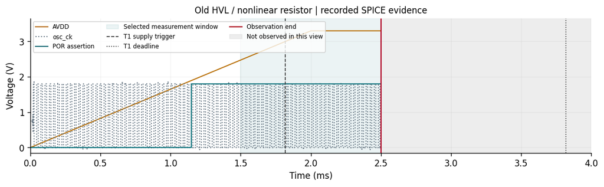

**After writing your explanation, reveal feedback**

Recorded execution: COMPLETE. Selected-window measurement: INVALID (no POR rising crossing of 0.9 V in the selected 1.5–2.5 ms window). Scalar bounds: NOT_EVALUATED. T1 function: INSUFFICIENT_EVIDENCE. AVDD crosses 3.0 V at 1.818 ms, so the T1 deadline is 3.818 ms. This view ends at 2.500 ms, before the deadline. Observe through the deadline before calling the missing response a failure. T1 is an educational assumption; neither this status nor an unchanged simulator exit code establishes full circuit compliance.

**Same old library: observe until 4 ms**

REAL RECORDED SPICE DATA · Python-precomputed check · no new simulation

Old HVL, nonlinear resistor, 2 ms supply ramp. Observe only through 4 ms. Gray space is unobserved; no future signal is drawn.

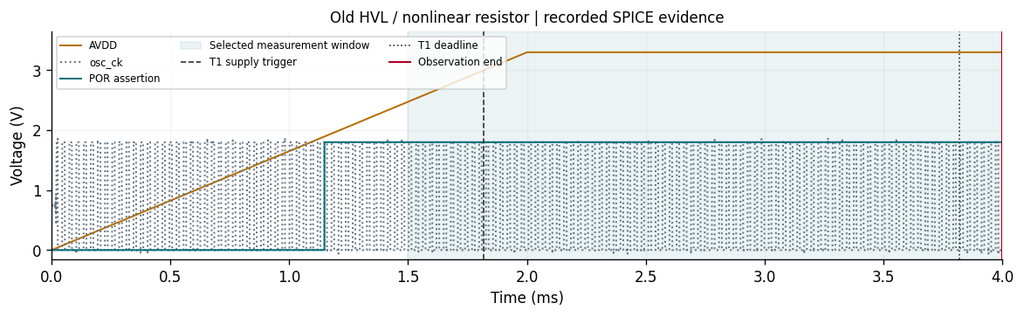

**After writing your explanation, reveal feedback**

Recorded execution: COMPLETE. Selected-window measurement: INVALID (no POR rising crossing of 0.9 V in the selected 1.5–4 ms window). Scalar bounds: NOT_EVALUATED. T1 function: FAIL. AVDD crosses 3.0 V at 1.818 ms, so the T1 deadline is 3.818 ms. The record covers that deadline while the supply stays valid, but no new POR rising edge appears after the trigger. An earlier high POR level does not satisfy this edge-based requirement. T1 is an educational assumption; neither this status nor an unchanged simulator exit code establishes full circuit compliance.

## 2 · Test a hypothesis

Predict what the corrected dependency changes. Name one alternative explanation and a falsifying observation.

**Before opening evidence:** record your prediction and reason on paper or in a text document. After observing, write your explanation before revealing feedback.

**Compare old and corrected libraries — predict the second plot**

REAL RECORDED SPICE DATA · Python-precomputed check · no new simulation

Change only the HVL dependency in this matched comparison. The SECOND case is the prediction target. The upstream correction is not our fix.

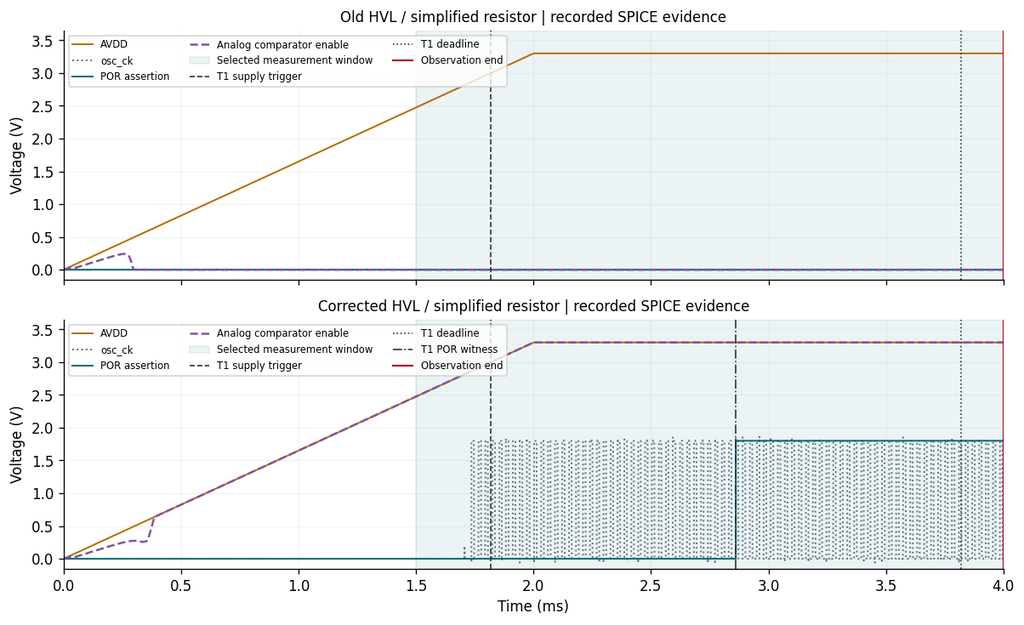

**After writing your explanation, reveal feedback**

Recorded execution: COMPLETE. Selected-window measurement: VALID (required ordered events observed). Scalar bounds: PASS. T1 function: PASS. AVDD crosses 3.0 V at 1.818 ms, so the T1 deadline is 3.818 ms. A new POR edge is observed at 2.861 ms, within the deadline. This witnesses the narrow T1 response. T1 is an educational assumption; neither this status nor an unchanged simulator exit code establishes full circuit compliance.

**Compare original and removed DC setting — predict the second plot**

REAL RECORDED SPICE DATA · Python-precomputed check · no new simulation

Matched original setup: remove only the AVDD DC override. This pair is separate from the later 1e-9 current-tolerance set. The SECOND case is the target.

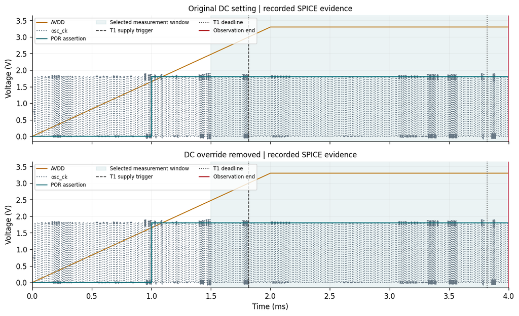

**After writing your explanation, reveal feedback**

Recorded execution: COMPLETE. Selected-window measurement: INVALID (no POR rising crossing of 0.9 V in the selected 1.5–4 ms window). Scalar bounds: NOT_EVALUATED. T1 function: FAIL. AVDD crosses 3.0 V at 1.818 ms, so the T1 deadline is 3.818 ms. The record covers that deadline while the supply stays valid, but no new POR rising edge appears after the trigger. An earlier high POR level does not satisfy this edge-based requirement. T1 is an educational assumption; neither this status nor an unchanged simulator exit code establishes full circuit compliance.

## 3 · Change one rule

Predict the effect of changing only the scalar upper limit from 2 ms to 1 ms. Which judgment changes?

**Before opening evidence:** record your prediction and reason on paper or in a text document. After observing, write your explanation before revealing feedback.

**Corrected record: maximum delay 2 ms**

REAL RECORDED SPICE DATA · Python-precomputed check · no new simulation

Same corrected nonlinear record. Extraction starts 1.5 ms at 0.9 V; scalar range 0.5–2 ms. T1 independently remains 3 V / 0.9 V / 2 ms.

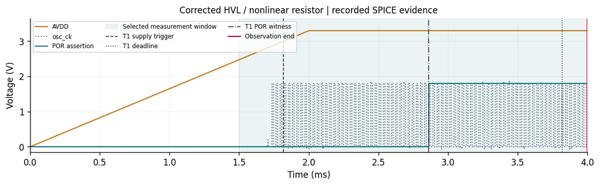

**After writing your explanation, reveal feedback**

Recorded execution: COMPLETE. Selected-window measurement: VALID (required ordered events observed). Scalar bounds: PASS. T1 function: PASS. AVDD crosses 3.0 V at 1.818 ms, so the T1 deadline is 3.818 ms. A new POR edge is observed at 2.862 ms, within the deadline. This witnesses the narrow T1 response. T1 is an educational assumption; neither this status nor an unchanged simulator exit code establishes full circuit compliance.

**Same corrected record: maximum delay 1 ms**

REAL RECORDED SPICE DATA · Python-precomputed check · no new simulation

Same corrected nonlinear record. Extraction starts 1.5 ms at 0.9 V; scalar range 0.5–1 ms. T1 independently remains 3 V / 0.9 V / 2 ms.

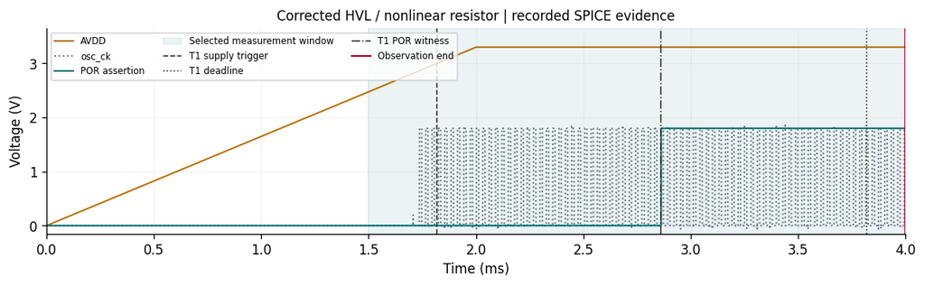

**After writing your explanation, reveal feedback**

Recorded execution: COMPLETE. Selected-window measurement: VALID (required ordered events observed). Scalar bounds: FAIL. T1 function: PASS. AVDD crosses 3.0 V at 1.818 ms, so the T1 deadline is 3.818 ms. A new POR edge is observed at 2.862 ms, within the deadline. This witnesses the narrow T1 response. T1 is an educational assumption; neither this status nor an unchanged simulator exit code establishes full circuit compliance.

## 4 · Independent challenge

Using only 4.4 ms of the slow-supply record, judge measurement and T1 separately. Write the next evidence request and a plain-language check.

**Before opening evidence:** record your prediction and reason on paper or in a text document. After observing, write your explanation before revealing feedback.

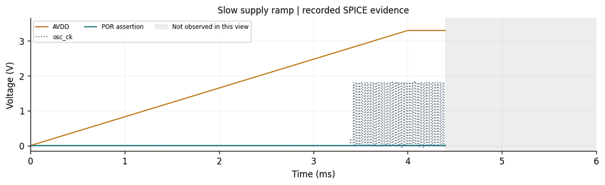

**Slow supply: inspect only the first 4.4 ms**

REAL RECORDED SPICE DATA · Python-precomputed check · no new simulation

Corrected HVL, nonlinear resistor, 4 ms AVDD ramp. Selected observation ends at 4.4 ms. This is a held-out view of a real record, not a new defect.

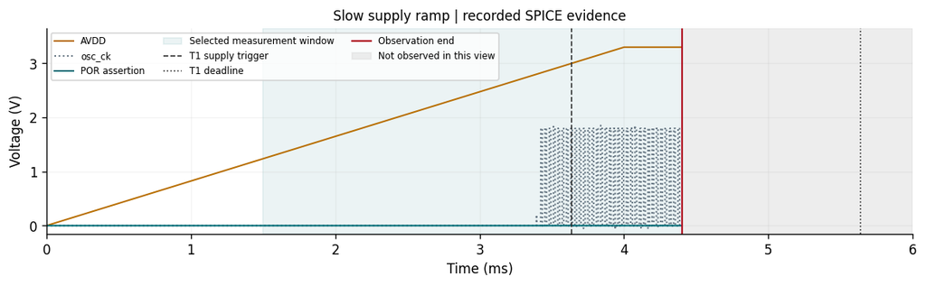

**After writing your explanation, reveal feedback**

Recorded execution: COMPLETE. Selected-window measurement: INVALID (no POR rising crossing of 0.9 V in the selected 1.5–4.4 ms window). Scalar bounds: NOT_EVALUATED. T1 function: INSUFFICIENT_EVIDENCE. AVDD crosses 3.0 V at 3.636 ms, so the T1 deadline is 5.636 ms. This view ends at 4.400 ms, before the deadline. Observe through the deadline before calling the missing response a failure. T1 is an educational assumption; neither this status nor an unchanged simulator exit code establishes full circuit compliance.

**Longer record — open only after your initial answer**

REAL RECORDED SPICE DATA · Python-precomputed check · no new simulation

Corrected HVL, nonlinear resistor, 4 ms AVDD ramp. Selected observation ends at 6 ms. This is a held-out view of a real record, not a new defect.

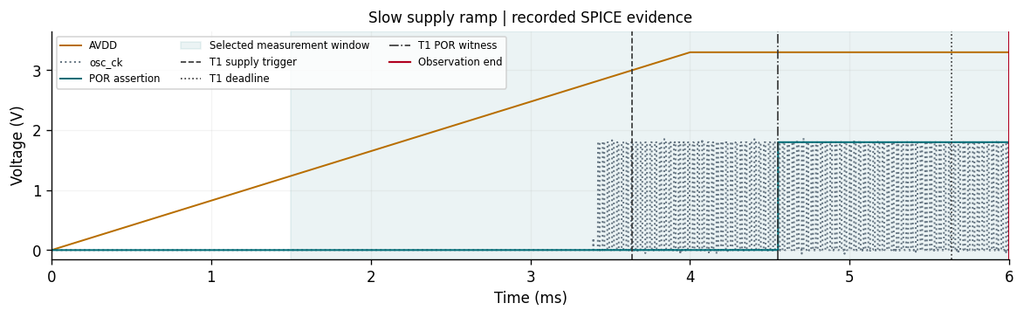

**After writing your explanation, reveal feedback**

Recorded execution: COMPLETE. Selected-window measurement: VALID (required ordered events observed). Scalar bounds: PASS. T1 function: PASS. AVDD crosses 3.0 V at 3.636 ms, so the T1 deadline is 5.636 ms. A new POR edge is observed at 4.552 ms, within the deadline. This witnesses the narrow T1 response. T1 is an educational assumption; neither this status nor an unchanged simulator exit code establishes full circuit compliance.